# Introduction to R

Notes for Ecuador workshops July-August 2017

Peter Alspach

July 2017

## Getting R and RStudio

R is available from [CRAN](http://cran.espol.edu.ec/), and many packages are also available there. Rstudio Desktop, open source, can be downloaded from [here](https://www.rstudio.com/products/rstudio/download/). Unless your employer has restricted administration rights on your computer, it is simplest to install accepting the defaults.

### Explore RStudio

- The panes
  - Code window (top left)
  - Console (bottom left)
  - Environment etc (top right)
  - Files, plots, packages and help (bottom right)
- Tools/Global Options…
- Projects

## R structure

### Environments

```r
search()
```

```r
ls() # illustrate the TAB key here
ls(pos=7)
ls('package:stats')
```

### Working directory

```r
getwd()
list.files()
setwd('../DataManagement') # note: forward slash
list.files()
```

### Packages

By default R comes with a number of packages. However, there are lots more (9000+) on [CRAN](http://cran.espol.edu.ec/) and elsewhere (e.g., [breedR](http://famuvie.github.io/breedR/), which breeders might be interested in installing). One can also write packages, but this is beyond the scope of this introductory course.

Once they have been installed they can be loaded onto the search path, either by checking the box in the RStudio Packages pane or `library(packageName)`.

```r
search()
library(DiGGer)
search() # DiGGer is now in the search path
```

### Getting help

- The TAB key in RStudio
- Search in the RStudio Help pane
- `help(functionName)` or `?functionName`

```r
# help(ls)
# ?ls
```

- Web-search your question (e.g., ‘Fitting mixed models in R’ or ‘Change background in ggplot2’)
- [R-help](https://stat.ethz.ch/mailman/listinfo/r-help)
- Ask a colleague or me (paalspach at gmail dot com)

## Basics

### Functions

These do the work, and have `arguments` in round brackets () separate by commas. If arguments are not explicitly named they are assumed to be in the order as specified in the help file (or using the TAB key). R is object oriented, which means that what a function does depends on the nature of the object upon which it is operating (see later).

By default, the output from a function is printed in the console (graphs are produced in the Plots pane). But the output can be saved to an R object using the assignment operator.

### R objects

This are vectors or lists.

```r
rm(list=ls()) # remove objects from the Global Environment (there probably aren't any)
ls() # check that nothing is there
c(1,3,4,7,2) # a vector with 5 integer elements is printed on the console window
ls() # but not saved
x <- c(1,3,4,7,2) # RStudio shortcut for the assignment operator is alt-
ls() # there is now an obect call x
ls.str() # this all gives the structure of the objects
print(x) # to run the print method for the object
x # shortcut for print(x)
```

## Working with data

### Reading data

There are lots of ways of getting data into R, but herein we concentrate on reading from a file with data. In particular, text files and Excel spreadsheets. Use `read.table` and its wrappers for text files. For Excel spreadsheets, we will use the `readxl` package.

```r
library(readxl)
# ?read_excel
examp3 <- read_excel('../DataManagement/ExerciseExample3.xls', 'Data', skip=7)
ls.str() # this is a 'tibble' which I don't like so ...
examp3 <- as.data.frame(examp3) # convert to a pure data.frame
# examp3 <- as.data.frame(read_excel('../DataManagement/ExerciseExample3.xls',
#                                    'Data', skip=7))
str(examp3)
```

We can look at this using the Environment pane of RStudio or using R functions.

```r
examp3
head(examp3) # just the first few rows
tail(examp3) # just the last few rows
```

### Accessing portions of the data

```r
dim(examp3) # 40 rows by 8 columns
examp3[1,] # first row.  Note square brackets [] for subsetting
examp3[1:3,] # first three rows
# What about the first column?
# Columns 2-4?
# The element in the first row, third column?
# Rows 1 and 3 (i.e., excluding 2)?
examp3[,3]          # these are ...
examp3[,'Cultivar'] # ... all the same ...
examp3$Cultivar     # ... thing
```

### Summarising the data

```r
summary(examp3)
# table(examp3) # gives a 8-way cross table which is not what we want
table(examp3[,3]) # that's better but a bit tedious for all columns
apply(examp3, 2, table) # apply(), and related functions, are useful
```

### Conditional subsetting

```r
examp3[examp3$Cultivar=='Cask',]
examp3[examp3$Wgt > 14,]
# Missing values are special
examp3[examp3$Wgt==NA,] # not what we want
examp3[is.na(examp3$Wgt),] # that's better
examp3[examp3$Wgt > 14 & !is.na(examp3$Wgt),]
examp3[examp3$Cultivar=='Cask' | examp3$Cultivar=='County',] # | for or
examp3[examp3$Cultivar %in% c('Cask','County'),]
examp3[substring(examp3$Cultivar, 1, 1)=='C',]
examp3[regexpr('[[:digit:]]', examp3$Cultivar)>0,]
```

The last few examples are getting complicated but illustrate what can be done. In particular, it is worth understanding [regular expressions](https://stat.ethz.ch/R-manual/R-devel/library/base/html/regex.html) ([here’s a cheatsheet](https://www.rstudio.com/wp-content/uploads/2016/09/RegExCheatsheet.pdf)).

### Changing types

```r
str(examp3)
```

Currently, `Rep` is numeric whereas it really should be a factor variate. That is, there is no reason to think of the value of Rep 1 as being half that of Rep 2. They are just different categories.

```r
examp3$Rep <- as.factor(examp3$Rep)
str(examp3)
examp3$Rep
```

#### More about factors

Factors are important, but they can be a little confusing. A factor has values, levels and labels - although sometimes these can be the same thing.

```r
(tc <- rep(c('one','two','three'), 2))
# The code above introduces two new features: the rep() function and the implied
# print() call achieve by wrapping the entire line in brackets ().
str(tc) # a character vector with 6 elements
tc+1 # generates an error since addition makes no sense for character vectors
```

```
## Error in tc + 1: non-numeric argument to binary operator
```

```r
levels(tc) # NULL since character vectors don't have levels
as.numeric(tc) # all missing
(tf <- as.factor(tc)) # by default levels are in alphabetical order of labels
str(tf) # a factor with 3 levels
tf+1 # generates an error
as.numeric(tf) # gives numbers, which are the level values (not level labels)

(tf1 <- factor(tc, levels=c('one','two','three'))) # override alphabetical default
as.numeric(tf1)

(tf2 <- factor(tc, levels=c('one','two','three','four'))) # override alphabetical default
tc[tc=='two'] <- 'four'
tf[tf=='two'] <- 'four'
tf1[tf1=='two'] <- 'four'
tf2[tf2=='two'] <- 'four'
data.frame(original=rep(c('one','two','three'), 2), tc=tc,
           tf=tf, tf1=tf1, tf2=tf2, stringsAsFactors=FALSE)
tf # still has 'two' as a factor level even though it is no longer used
factor(tf) # has dropped the unused factor level

# Beware the following trap
(trap <- factor(c(8.9, 9.8, 10.1)))
as.numeric(trap) # gives the level values
as.numeric(as.character(trap)) # by first converting to character this is avoided
```

### Editing values

As mentioned in the Data Management seminar, any editting of the raw data should be done using code so that it can be repeated (and the raw data is not corrupted). We have already seen how to change individual values. One might also wish to transform values. For example, the code below adjusts the weight according to the moisture content[^1].

```r
examp3$DW <- examp3$Wgt/(1+examp3$Moist/100)
examp3$DWtha <- 10*examp3$DW/(12.8*1.62) # should get plot size from spreadsheet
head(examp3[,-c(1,8)])
```

#### The `tidyverse`

Hadley Wickham (hadley@rstudio.com) has contributed greatly to the R Community and thought a good deal about semantics and [tidying data](https://www.jstatsoft.org/index.php/jss/article/view/v059i10). The packages he has created to facilitate tidying data are collectively known as the [‘tidyverse’](http://tidyverse.org/). These packages include `dplyr`, `magrittr`and `tidyr`. The easiest way to get access is to install the entire tidyverse (`install.packages('tidyverse')`).

This introduction does not cover the ‘tidyverse’, but it is well worth looking at the documentation and tutorials on the web. There are [various cheatsheets](https://www.rstudio.com/resources/cheatsheets/) maintained by RStudio. Some of these have been translated into Spanish:

- [Data import](https://github.com/rstudio/cheatsheets/raw/master/translations/spanish/data-import-cheatsheet_Spanish.pdf)
- [Data wrangling](https://www.rstudio.com/wp-content/uploads/2015/03/data-wrangling-spanish.pdf)
- Data visualisation using [ggplot2](https://www.rstudio.com/wp-content/uploads/2016/12/ggplot2-cheatsheet-2.1-Spanish.pdf)
- [R markdown](https://www.rstudio.com/wp-content/uploads/2015/03/rmarkdown-spanish.pdf)
- [Package development](https://www.rstudio.com/wp-content/uploads/2015/03/devtools-spanish.pdf), for more advanced users.

### Writing or saving data

When leaving R, one can save the `workspace`. That is, all objects in the Global Environment. This is generally not advisable. However sometimes it is good to save some objects (perhaps output from a model that took a few hours to fit).

```r
# save(RObj1, RObj2, ..., file='myObjects.RData')
# load('myObjects.RData')
```

The resulting file, myObjects.RData, retains the structure of the R objects (which is good) but is not readily interoperable using other software (which is bad). The base R function for writing a flat table as a text file is `write.table` and there are also packages for writing Excel files.

```r
filePath <- '../RNotes'
filename <- paste0(filePath, '/Example3')

write.table(examp3, paste0(filename, '.txt'), sep='\t', na='*')

library(openxlsx) # if not installed get from CRAN
# installr::install.rtools() # requires installr from CRAN.  Takes about 10-15 minutes
write.xlsx(examp3, paste0(filename, '.xlsx'), sheetName='Example3 from openxlsx',
           keepNA=TRUE, firstRow=TRUE)
```

Creating and writing to Excel files requires extra software (in the case of `openxlsx` this is RTools) which entails some extra hassle if it is not already installed.

## Base graphics

Characteristics of a good scientific graph include

- Accurate representation of the data
- Clarity
- Appropriate use of colours
- Maximised information to ink ratio (i.e., not chart junk)
- It tells a good story (better than can be done with words or a table)

Base R has lots of graphics features, and there are lots of packages for further extending visualisation (including interactive graphics).

```r
ls('package:graphics')
```

Note the different variants of some of these functions (e.g., `plot.default`, `plot.function` and so on). Which is actually called when one issues a `plot` call depends on the nature of the object.

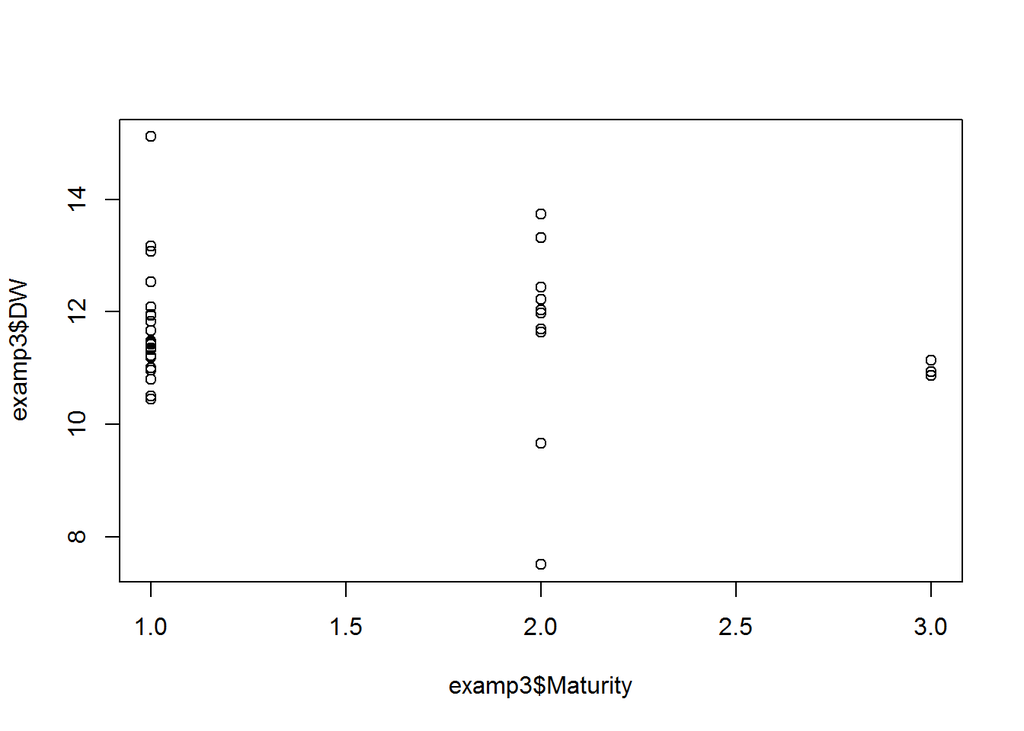

```r
plot(examp3$Maturity, examp3$DW)
```

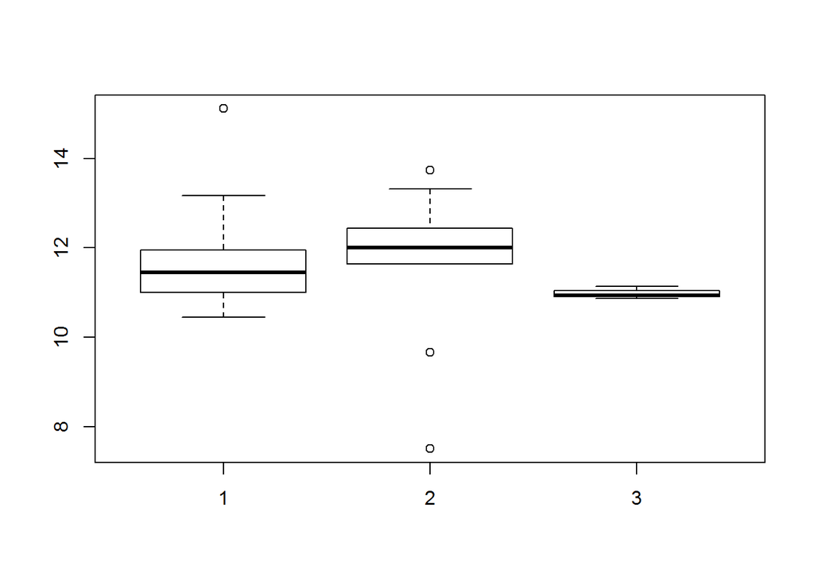

```r
plot(factor(examp3$Maturity), examp3$DW)
```

### Graphics parameters

The appearance of the graphs can be adjusted using the graphics parameters (`par()` will show the current parameters). One can adjust margin size, axes and labels appearance, the number of plots on a page (although for greater flexibility one needs to use `layout()`), and many other aspects. Some of these will be illustrated in what follows.

### Scatterplot

We will explore graphically whether there is a relationship between weight and height.

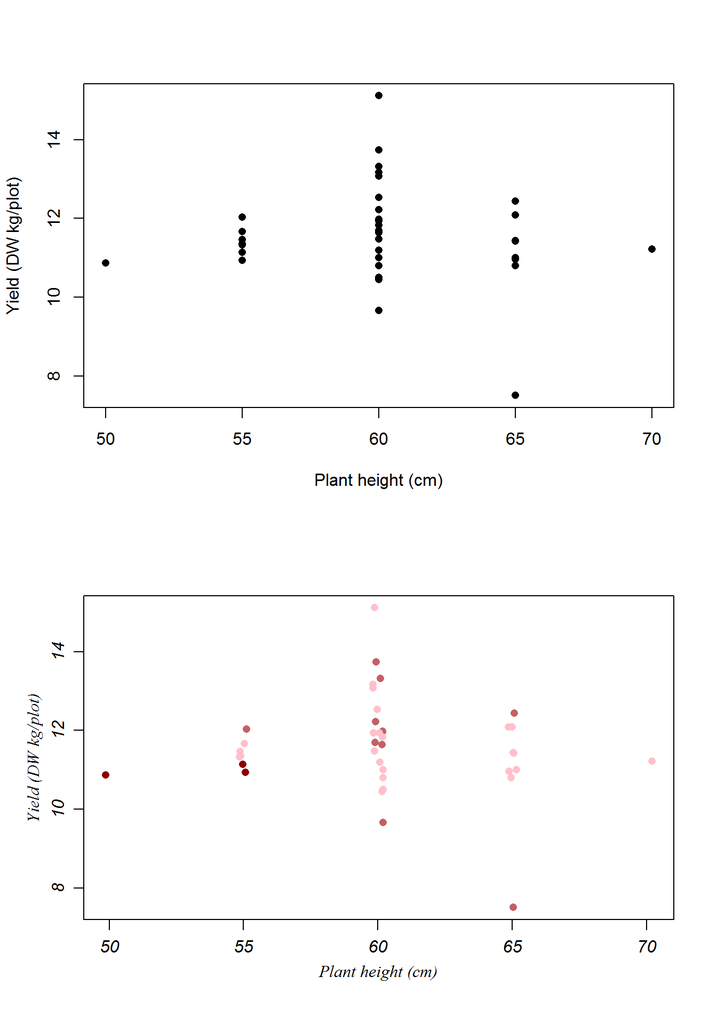

```r
par(mfrow=c(2,1))
plot(examp3$Height, examp3$DW, xlab='Plant height (cm)', ylab='Yield (DW kg/plot)',
     pch=16)
par(mgp=c(2, 0.8, 0), font.axis=3, font.lab=8)
plot(jitter(examp3$Height, 0.2), examp3$DW, xlab='Plant height (cm)', ylab='Yield (DW kg/plot)',
     pch=16, col=colorRampPalette(c('pink', 'darkred'))(3)[examp3$Maturity])
```

The code above illustrates a small fraction of the possibilies. Note

- `par` adjustments were
  - `mfrow` (**m** ultiple **f** rames by **row**) to give a plot window with 2 rows and 1 column
  - `mgp` (**m** argin **g** raphics **p** arameters) to adjust the position of the axes labels
  - `font.axis` and `font.lab` to adjust the font of the axes titles and labels (one would not usually choose these particular fonts)
- The `plot` refinements include
  - `xlab` and `ylab` to label the axes. `main` would give the plot a title
  - `pch` (**p** lotting **ch** aracter) to choose the point style. `cex` (**c** haracter **ex** tension) would change the size
  - `col` to change the colour of the points, in this case to reflect the maturity score. The `colorRampPalette` function is useful when one wants the colour to reflect a numeric or ordinal variate
  - `jitter` to add a bit of (horizontal) noise to reduce the overlap of points

### `ggplot2`

This part of Hadley Wickham’s contribution. Many people prefer it over base graphs. The [cheatsheet](https://www.rstudio.com/wp-content/uploads/2016/12/ggplot2-cheatsheet-2.1-Spanish.pdf) should help you get started.

## Linear models

### Analysis of variance

If the design is balanced with no missing plots or covariates, using `aov` to fit the linear model has some advantages in terms of ease of use. However, when this is not the case (i.e., most practical situations) `lm` is generally used

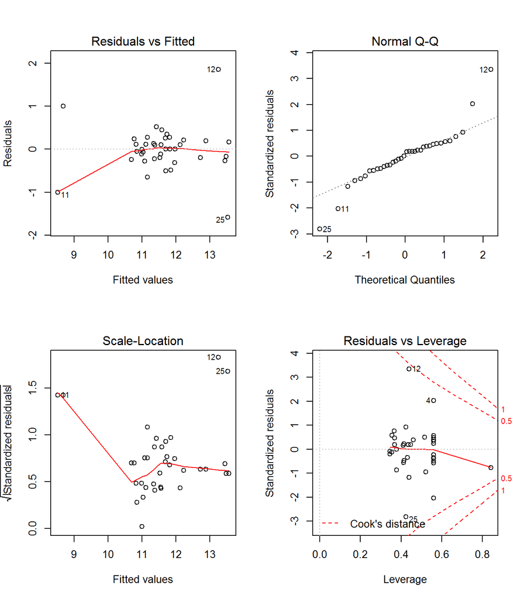

```r
par(mfrow=c(2,2))
examp3$Cultivar <- factor(examp3$Cultivar)
ex3AOV <- aov(DW~Maturity*Cultivar+Rep, data=examp3)
plot(ex3AOV)
```

```r
anova(ex3AOV)
```

```
## Analysis of Variance Table
##
## Response: DW
##                   Df Sum Sq Mean Sq F value    Pr(>F)
## Maturity           1  0.893  0.8935  1.6284 0.2173082
## Cultivar           9 36.319  4.0354  7.3544 0.0001388 ***
## Rep                3  2.063  0.6877  1.2533 0.3184640
## Maturity:Cultivar  6  4.969  0.8282  1.5094 0.2283743
## Residuals         19 10.425  0.5487
## ---
## Signif. codes:  0 '***' 0.001 '**' 0.01 '*' 0.05 '.' 0.1 ' ' 1
```

### Regression

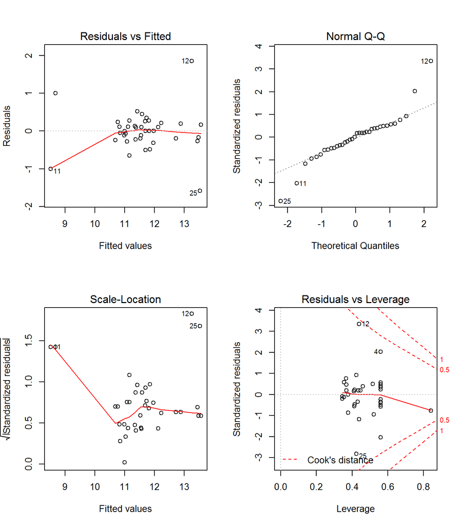

```r
par(mfrow=c(2,2))
ex3LM <- lm(DW~Maturity*Cultivar+Rep, data=examp3)
plot(ex3LM)
```

```r
anova(ex3LM)
```

```
## Analysis of Variance Table
##
## Response: DW
##                   Df Sum Sq Mean Sq F value    Pr(>F)
## Maturity           1  0.893  0.8935  1.6284 0.2173082
## Cultivar           9 36.319  4.0354  7.3544 0.0001388 ***
## Rep                3  2.063  0.6877  1.2533 0.3184640
## Maturity:Cultivar  6  4.969  0.8282  1.5094 0.2283743
## Residuals         19 10.425  0.5487
## ---
## Signif. codes:  0 '***' 0.001 '**' 0.01 '*' 0.05 '.' 0.1 ' ' 1
```

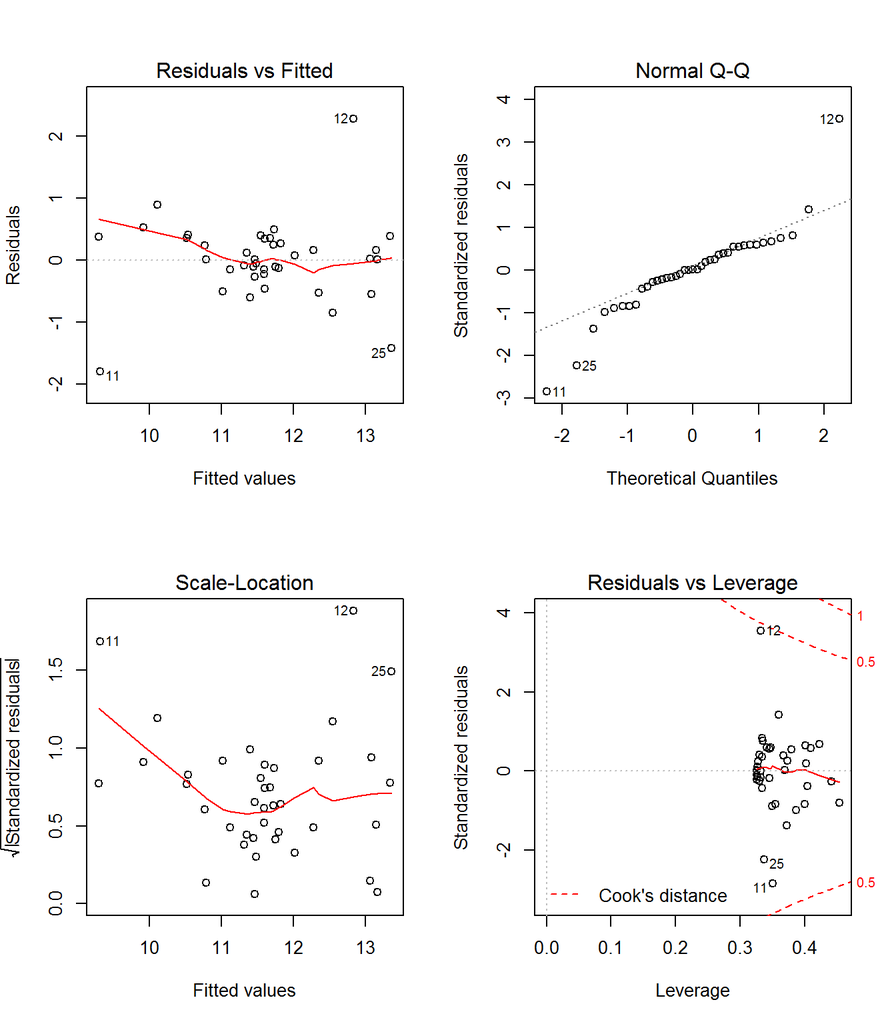

```r
ex3LM <- lm(DW~Maturity+Cultivar+Rep, data=examp3)
plot(ex3LM)
```

```r
anova(ex3LM)
```

```
## Analysis of Variance Table
##
## Response: DW
##           Df Sum Sq Mean Sq F value    Pr(>F)
## Maturity   1  0.893  0.8935  1.4510    0.2396
## Cultivar   9 36.319  4.0354  6.5533 9.022e-05 ***
## Rep        3  2.063  0.6877  1.1168    0.3610
## Residuals 25 15.395  0.6158
## ---
## Signif. codes:  0 '***' 0.001 '**' 0.01 '*' 0.05 '.' 0.1 ' ' 1
```

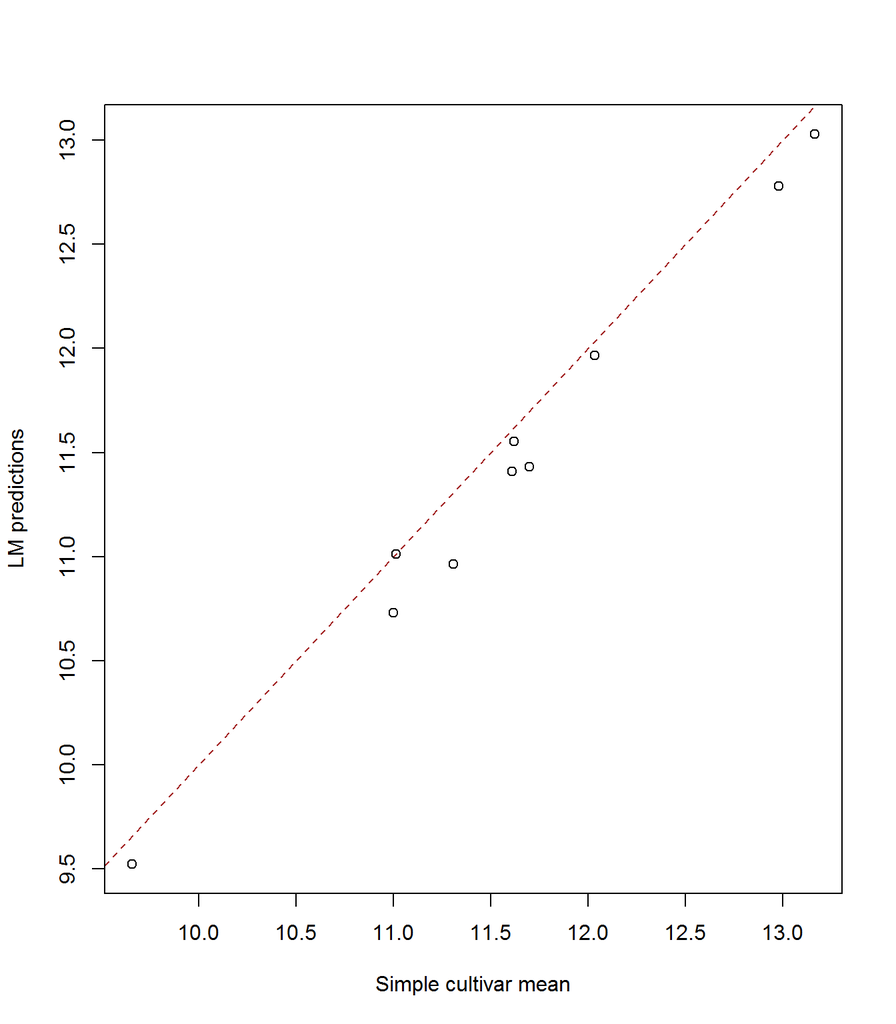

```r
ND <- expand.grid(Cultivar=levels(examp3$Cultivar), Rep=1:4, Maturity=1:3)
ND$Rep <- factor(ND$Rep)
lmPred <- predict(ex3LM, newdata=ND, se=TRUE)
ND$pred <- lmPred$fit
ND$se <- lmPred$se.fit

par(mfrow=c(1,1))
plot(tapply(examp3$DW, examp3$Cultivar, mean, na.rm=TRUE),
     tapply(ND$pred, ND$Cultivar, mean, na.rm=TRUE),#lmPred$fit,
     xlab='Simple cultivar mean', ylab='LM predictions',
     panel.first=abline(0, 1, col='brown', lty='dashed'))
```

### Linear mixed models

These models are more complex, but are better for unbalanced data (either due to design, missing values, or other circumstance). The main R package for fitting them is [lme4](https://cran.r-project.org/web/packages/lme4/index.html) which has an [large manual](https://cran.r-project.org/web/packages/lme4/lme4.pdf) and several vignettes, [one of which](https://cran.r-project.org/web/packages/lme4/lme4.pdf) is similar to the [2015 paper in JSS](https://www.jstatsoft.org/article/view/v067i01/v67i01.pdf).

## Other possible topics

If time permits we might also cover

- The `apply` series of functions
- Writing functions
- More about markdown
- Using git and github for collabortive research
- Generalised linear models (`glm`) which are particularly useful for binomial (presence/absence) and count data
- `breedR`
[^1]: Note: the information in the spreadsheet is not clear as to whether the Wgt is dry weight or wet weight, and whether moisture content is computed on a dry weight basis or wet weight basis